# Logbook_Jasper

In this Logbook you can find the flow of the minor me and Ramon are doing.

We are doing an research about the affect of different drugs with in the ROS1-positive NSCLC

The ROS1 gene is normally not actively expressed in most human adult tissues. Under normal physiological conditions, ROS1 activity is very low or absent, meaning it does not continuously send growth signals to cells.

However, genomic alterations such as **chromosomal rearrangements** or **gene fusions** can lead to abnormal activation of ROS1. These mutations place the ROS1 kinase domain under the control of an alternative promoter or create a constitutively active fusion protein. As a result, the ROS1 gene becomes transcribed and translated, leading to persistent expression of an active receptor tyrosine kinase.

Activated ROS1 continuously sends intracellular signals independent of normal regulatory mechanisms. This results in activation of multiple downstream signaling pathways.

Continuous activation of these pathways promotes cell proliferation, survival, and resistance to apoptosis. Over time, this uncontrolled signaling can contribute to tumor initiation and cancer progression.

The lab asked us to look at some interesting genes and make primes for them.

In the powerpoint presentaion we got where some genes shown with intresting interaction with in the patways. We are goinig to use these given pathways to look to intresting genes.

Ofcourse we need ros1

Based on the pathways provided in the PowerPoint presentation, several genes were selected that show important interactions within the PI3K–AKT, MAPK, and JAK–STAT signaling pathways. These genes were chosen because of their roles in signal transduction, cell growth, survival, and apoptosis regulation.

### PI3K–AKT Signaling Pathway

| Gene | Why |
| --- | --- |
| **AKT** | Central kinase in the pathway that regulates many downstream cellular processes including survival and growth. |
| **GRB2** | Early adaptor protein linking receptor activation to downstream signaling; also involved in the MAPK pathway, allowing pathway comparison. |
| **PI3KCA** | Key signaling molecule that integrates multiple upstream signals and activates AKT. |
| **MDM2** | Regulates the tumor suppressor protein p53 and influences cell cycle control. |
| **FOXO3** | Transcription factor involved in cell survival, metabolism, and cell cycle regulation. |
| **GSK3B** | Downstream target of AKT involved in metabolism and cell proliferation regulation. |
| **TSC1/TSC2** | Protein complex regulating mTOR signaling and cellular growth control. |

[figure not shown]

Image of PI3K-akt pathway and the chosen genes

### MAPK Signaling Pathway

| Gene | Why |
| --- | --- |
| **GRB2** | Shared component with the PI3K–AKT pathway, enabling comparison between signaling routes. |
| **RAS** | Important regulator of cell proliferation and signal amplification. |
| **MEKK1** | Kinase involved in transmitting signals downstream within the MAPK cascade. |

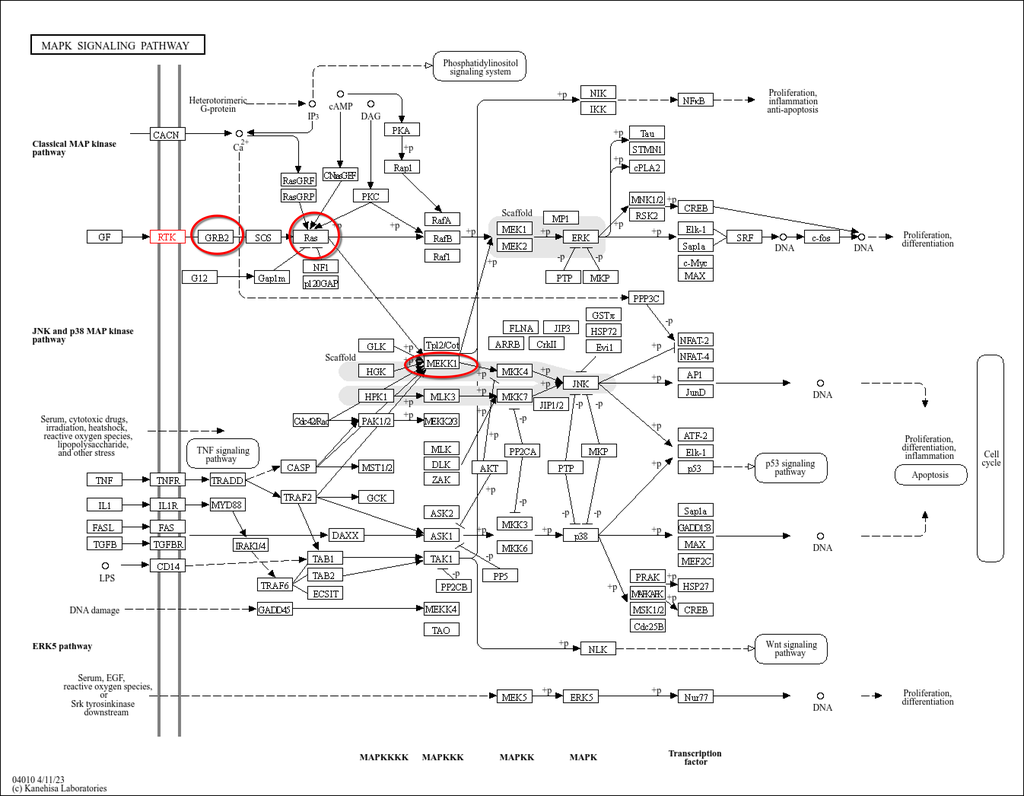

Image of MAPK pathway and the chosen genes

### JAK–STAT Signaling Pathway

| Gene | Why |
| --- | --- |
| **TYK2** | Identified in the presentation as an important signaling kinase within the pathway. |
| **JAK1/2** | Early signaling kinases essential for pathway activation and signal propagation. |
| **PI3K** | Acts as a signaling integration point connecting JAK–STAT with other pathways. |
| **BCL2** | Anti-apoptotic protein promoting cell survival. |
| **PIAS** | Negative regulator that inhibits STAT signaling and limits pathway activation. |

[figure not shown]

Image of JAK-STAT pathway and the chosen genes

This are genes we are moste intrested in for out research. But we need some reserves because our teacher of the lab wanted it. She asked about some housekeeping genes this are genes who expres normal when there is tumor tisue

We have some more genes

| Gene | Why |
| --- | --- |
| GAPDH | housekeeping gene |
| B-actine | housekeeping gene |
| PIK3CG | Imporant gene in PI3K-akt pathway |
| B2M | housekeeping gene |
| CREB1 | Gene for cell cycle, PI3K-Akt signaling pathway |
| MAP3K14 | It plays a crucial role in immune system regulation, MAPK signaling pathway |
| ELK1 | ternary complex factor, MAPK signaling pathway |
| CISH | In JAK-STAT signaling pathway |
| PIK3CA | Imporant gene in PI3K-akt pathway |
| ARID1a | a key tumor suppressor gene |

# End result for the genes

Here we have all the genes and in wich pathway they have influnece

| Gen | Forward primer (5’→3’) | Reverse primer (5’→3’) | Tm F (°C) | Tm R (°C) | Reason |
| --- | --- | --- | --- | --- | --- |
| GAPDH | TGCACCACCAACTGCTTAGC | GGCATGGACTGTGGTCATGAG | 61.17 | 61.02 | Housekeeping gene |
| ROS1 (exon 40–41) | GGATGGCTCCAGAAAGTTTG | GGATAAGGCTGATGACCAAG | 56.69 | 55.59 | Important because it is ros1 |
| ROS1 | TGTTGACGGGACACACAGAC | GGTATCCCCAGTGCTCTGTC | 60.18 | 59.53 | Important because it is ros1 |

## PI3K-akt pathway

| Gen | Forward primer (5’→3’) | Reverse primer (5’→3’) | Tm F (°C) | Tm R (°C) | Reason |
| --- | --- | --- | --- | --- | --- |
| PIK3CG | ACCATGAAGGAAACCAGTCG | GCCTTCATCTGCTCCACGTT | 57.81 | 60.67 | Is an important gene that strats a lot |
| CREB1 | GTGTGTTACGTGGGGGAGAG | CTGCTGGCATAGATACCTGGG | 60.04 | 60.00 | Downstream gene for gense survival |
| MDM2 | TGGTGAGGAGCAGGCAAATG | TGGCACGCCAAACAAATCTC | 60.61 | 59.69 | Downstream gene for gense survival for p53 pathway |
| GSK3B | CTCAGGAGTGCGGGTCTTC | AAGAGTGCAGGTGTGTCTCG | 59.78 | 59.97 | Downstream gene that get stopt by PIK3CG |
| TSC1 | AACCTGTAGCACACGTCCTG | CCTGTCCAAGAGGTGCTTGT | 59.97 | 59.89 | Gene for protein synthese |
| TSC2 | CTGCGGTCCAATGTCCTCTT | GACGTCTGTATCCTGCTGCG | 60.04 | 60.87 | Gene for protein synthese |
| DDIT4 | CTGTCCTCACCATGCCTAGC | ATCCAGGTAAGCCGTGTCTTC | 60.18 | 59.79 | Gene form other pathway that has influce in this pathway |

## MAPK Signaling Pathway

| Gen | Forward primer (5’→3’) | Reverse primer (5’→3’) | Tm F (°C) | Tm R (°C) |  |
| --- | --- | --- | --- | --- | --- |
| GRB2 | TGGGGACTTCTCCCTCTCTG | GACGTATGTCGGCTGCTGTG | 59.96 | 61.41 | First gene in this pathway after ros1 |
| MAP3K1 | CTCTTCCTTGCCGCCTCAC | TTCTCCATCTCACGACCGGC | 60.74 | 61.95 | Gene in the middle of the pathway |
| MAPK14 | GCATAATGGCCGAGCTGTTG | TCATGGCTTGGCATCCTGTT | 59.97 | 59.96 | Downstream gene |
| ELK1 | CCCGTCCGTGGCCTTATTTA | CTCTGCATCCACCAGCTTGA | 59.82 | 60.04 | Downstream gene has influnce on p53 |
| RPTOR | CTGTCGGCATCTTCCCCTAC | CGGTGTTCAGCTGGCATGT | 59.89 | 60.97 | Down stream gene |

## JAK–STAT Signaling Pathway

| Gen | Forward primer (5’→3’) | Reverse primer (5’→3’) | Tm F (°C) | Tm R (°C) |  |
| --- | --- | --- | --- | --- | --- |
| TYK2 | GCTCAATGTAGTCCCAGCCTT | AGACGTCAGCAAGATTGTGGG | 60.07 | 60.61 | An early gene |
| JAK2 | CTGGTCGCCCGATCTGTGTA | TCAGAACATTTGCCGTCGC | 61.66 | 59.13 | One of the firts genes |
| PIAS3 | AGCTGGGCGAATTAAAGCACA | TCATCTGGACACTAGGGGCA | 60.89 | 59.96 | Influnce on dna |
| CISH | GGACATGGTCCTCTGCGTT | CAAAGGACGAGGTCTGGGCA | 59.70 | 62.11 | Stops Jak2 |

Mean while there are some result of the lab that we show here

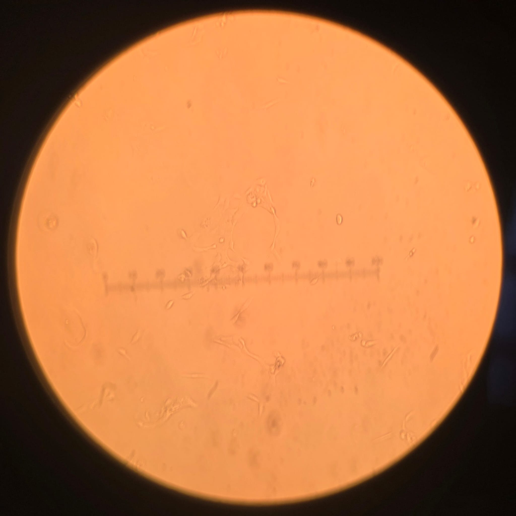

Before incubation with medicine en dsmo

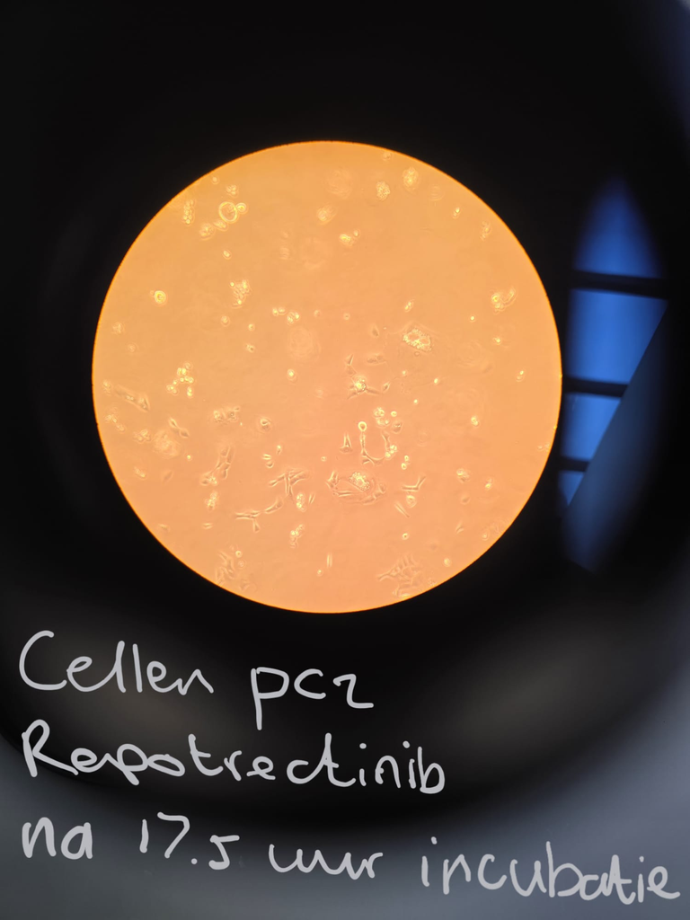

After 17.5 hours incbartion time

# Data analysis

Now we are going to do an analysis on data from two different studies that are provided by our supervisor. This data you can compare with our data so if we can make an beautiful little pipeline, we can make an snakemake pipeline and when the data arrives we can put this data in our pipeline.

The use of star and annotaion of the data is done by Ramon

I maded the coldata for the two data sets so we can do desseq2 with the data.

I am going to work with the data from GSE214715. In this study they are working with the human genome h19.. So we are going to do desseq2 once for h19 and one time with the h38 so we can see the difference in results.

So first we need to read the data in.

```r
coldata <- read.csv("/students/2025-2026/ros1_transcriptomics/GSE214715/col_data/coldata.csv",sep = ";")

coldata
```

```
##                     source  genotype         treatment
## 1  SRR21789607ReadsPerGene CD74-ROS1 500nM entrectinib
## 2  SRR21789608ReadsPerGene CD74-ROS1 500nM entrectinib
## 3  SRR21789609ReadsPerGene CD74-ROS1 500nM entrectinib
## 4  SRR21789610ReadsPerGene CD74-ROS1 500nM entrectinib
## 5  SRR21789611ReadsPerGene CD74-ROS1 500nM entrectinib
## 6  SRR21789612ReadsPerGene CD74-ROS1 500nM entrectinib
## 7  SRR21789613ReadsPerGene CD74-ROS1              none
## 8  SRR21789614ReadsPerGene CD74-ROS1              none
## 9  SRR21789615ReadsPerGene CD74-ROS1              none
## 10 SRR21789616ReadsPerGene TPM3-ROS1 500nM entrectinib
## 11 SRR21789617ReadsPerGene TPM3-ROS1 500nM entrectinib
## 12 SRR21789618ReadsPerGene TPM3-ROS1 500nM entrectinib
## 13 SRR21789620ReadsPerGene TPM3-ROS1 500nM entrectinib
## 14 SRR21789621ReadsPerGene TPM3-ROS1              none
## 15 SRR21789622ReadsPerGene TPM3-ROS1              none
## 16 SRR21789623ReadsPerGene TPM3-ROS1              none
```

```r
count_data_hg19 <- read.csv("/students/2025-2026/ros1_transcriptomics/GSE214715/counts/hg19_counts.csv", row.names = 1)
head(count_data_hg19)
```

```
##        SRR21789607ReadsPerGene SRR21789608ReadsPerGene SRR21789609ReadsPerGene
## TSPAN6                     570                     777                     505
## TNMD                         0                       0                       0
## DPM1                       738                     811                     674
## SCYL3                      142                     128                      60
## FIRRM                      258                     217                     148
## FGR                          0                       0                       0
##        SRR21789610ReadsPerGene SRR21789611ReadsPerGene SRR21789612ReadsPerGene
## TSPAN6                     610                     476                     522
## TNMD                         0                       0                       0
## DPM1                       611                     494                     516
## SCYL3                       98                      95                     105
## FIRRM                      114                     107                     116
## FGR                          0                       1                       0
##        SRR21789613ReadsPerGene SRR21789614ReadsPerGene SRR21789615ReadsPerGene
## TSPAN6                    1805                    1692                    1037
## TNMD                         0                       0                       0
## DPM1                       524                     751                     477
## SCYL3                      239                     211                     169
## FIRRM                      188                     170                     211
## FGR                          0                       0                       0
##        SRR21789616ReadsPerGene SRR21789617ReadsPerGene SRR21789618ReadsPerGene
## TSPAN6                    2049                    2101                    1090
## TNMD                         0                       0                       0
## DPM1                      1235                    1254                    1513
## SCYL3                      149                     208                     125
## FIRRM                      302                     271                     335
## FGR                          0                       0                       0
##        SRR21789620ReadsPerGene SRR21789621ReadsPerGene SRR21789622ReadsPerGene
## TSPAN6                    1602                    2150                    1542
## TNMD                         0                       0                       0
## DPM1                      1845                    1185                    1085
## SCYL3                      105                     128                     128
## FIRRM                      261                     238                     262
## FGR                          3                       3                       3
##        SRR21789623ReadsPerGene
## TSPAN6                    1634
## TNMD                         0
## DPM1                      1135
## SCYL3                      170
## FIRRM                      215
## FGR                          0
```

```r
count_data_hg38 <- read.csv("/students/2025-2026/ros1_transcriptomics/GSE214715/counts/hg38_counts.csv",row.names = 1)
head(count_data_hg38)
```

```
##        SRR21789607ReadsPerGene SRR21789608ReadsPerGene SRR21789609ReadsPerGene
## TSPAN6                     581                     791                     510
## TNMD                         0                       0                       0
## DPM1                       437                     414                     344
## SCYL3                       96                      88                      34
## FIRRM                      262                     218                     149
## FGR                          0                       0                       0
##        SRR21789610ReadsPerGene SRR21789611ReadsPerGene SRR21789612ReadsPerGene
## TSPAN6                     619                     486                     533
## TNMD                         0                       0                       0
## DPM1                       318                     287                     291
## SCYL3                       53                      60                      54
## FIRRM                      114                     107                     116
## FGR                          0                       1                       0
##        SRR21789613ReadsPerGene SRR21789614ReadsPerGene SRR21789615ReadsPerGene
## TSPAN6                    1836                    1722                    1065
## TNMD                         0                       0                       0
## DPM1                       292                     404                     303
## SCYL3                      185                     138                     127
## FIRRM                      194                     173                     214
## FGR                          0                       0                       0
##        SRR21789616ReadsPerGene SRR21789617ReadsPerGene SRR21789618ReadsPerGene
## TSPAN6                    2068                    2121                    1106
## TNMD                         0                       0                       0
## DPM1                       736                     773                     870
## SCYL3                      100                     159                      82
## FIRRM                      304                     273                     339
## FGR                          0                       0                       0
##        SRR21789620ReadsPerGene SRR21789621ReadsPerGene SRR21789622ReadsPerGene
## TSPAN6                    1637                    2171                    1560
## TNMD                         0                       0                       0
## DPM1                      1030                     630                     559
## SCYL3                       73                      89                      75
## FIRRM                      264                     238                     266
## FGR                          3                       5                       3
##        SRR21789623ReadsPerGene
## TSPAN6                    1655
## TNMD                         0
## DPM1                       618
## SCYL3                      108
## FIRRM                      216
## FGR                          0
```

```r
library("DESeq2")
```

```r
desseq_for_CD74_ROS1 <- coldata$genotype == "CD74-ROS1"

dds_hg19_CD74 <- DESeqDataSetFromMatrix(countData = count_data_hg19[,desseq_for_CD74_ROS1],
                              colData = coldata[desseq_for_CD74_ROS1,],
                              design = ~ treatment)
dds_hg19_CD74 <- DESeq(dds_hg19_CD74)
res_hg19_CD74 <- results(dds_hg19_CD74)
```

```r
dds_hg38 <- DESeqDataSetFromMatrix(countData = count_data_hg38[,desseq_for_CD74_ROS1],
                              colData = coldata[desseq_for_CD74_ROS1,],
                              design = ~ treatment)
dds_hg38 <- DESeq(dds_hg38)
res_hg38 <- results(dds_hg38)
```

## Plots

### hg 19

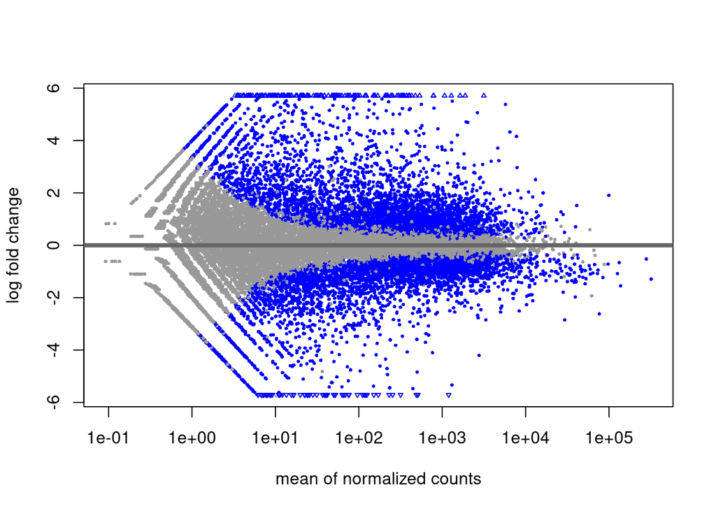

```r
plotMA(res_hg19_CD74)
```

```r
res_df_hg19_CD74 <- as.data.frame(res_hg19_CD74)
res_df_hg19_CD74$gene <- rownames(res_df_hg19_CD74)
head(res_df_hg19_CD74)
```

```
##           baseMean log2FoldChange     lfcSE       stat       pvalue
## TSPAN6 855.3676037      1.2332398 0.1834560  6.7222637 1.789228e-11
## TNMD     0.0000000             NA        NA         NA           NA
## DPM1   618.0229058     -0.2703597 0.2009477 -1.3454236 1.784885e-01
## SCYL3  133.7406182      0.8570617 0.2036685  4.2081216 2.575022e-05
## FIRRM  166.7028257      0.1565608 0.2728152  0.5738714 5.660548e-01
## FGR      0.1208251     -0.6154018 3.5338177 -0.1741464 8.617504e-01
##                padj   gene
## TSPAN6 4.122267e-10 TSPAN6
## TNMD             NA   TNMD
## DPM1   3.119120e-01   DPM1
## SCYL3  1.732979e-04  SCYL3
## FIRRM  7.025243e-01  FIRRM
## FGR              NA    FGR
```

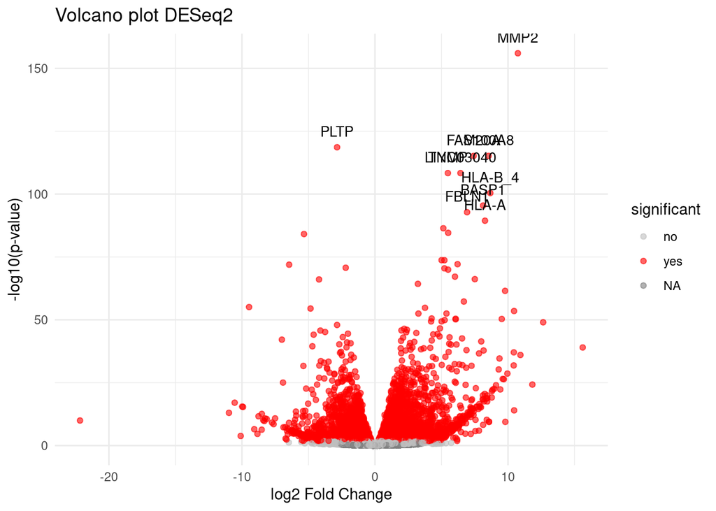

```r
library(ggplot2)
library(dplyr)

res_df_hg19_CD74 <- res_df_hg19_CD74 %>%
  mutate(significant = ifelse(padj < 0.05, "yes", "no"))


top_genes <- res_df_hg19_CD74 %>%
  filter(!is.na(padj)) %>%
  arrange(padj) %>%
  slice(1:10)


ggplot(res_df_hg19_CD74, aes(x = log2FoldChange, y = -log10(pvalue))) +
  geom_point(aes(color = significant), alpha = 0.6) +
  scale_color_manual(values = c("no" = "grey", "yes" = "red")) +
  geom_text(data = top_genes,
            aes(label = gene),
            vjust = -1,
            size = 3.5) +
  theme_minimal() +
  labs(title = "Volcano plot DESeq2",
       x = "log2 Fold Change",
       y = "-log10(p-value)")
```

```r
rld_hg19 <- rlog(dds_hg19_CD74, blind=T)
```

```
## -- note: fitType='parametric', but the dispersion trend was not well captured by the
##    function: y = a/x + b, and a local regression fit was automatically substituted.
##    specify fitType='local' or 'mean' to avoid this message next time.
```

```r
pcaData_hg19 <- plotPCA(rld_hg19, intgroup = c("genotype","treatment"), returnData = TRUE)
```

```
## using ntop=500 top features by variance
```

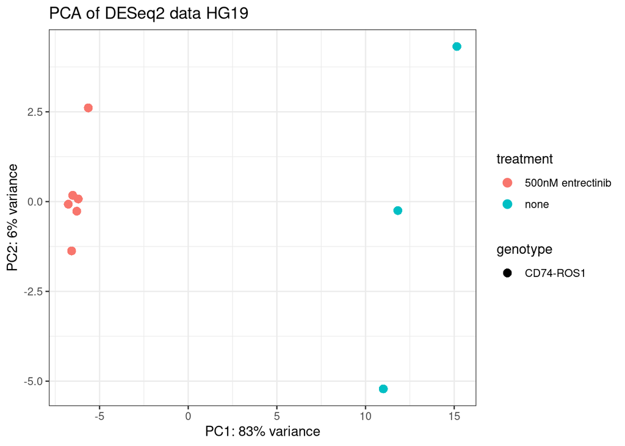

```r
percentVar <- round(100 * attr(pcaData_hg19, "percentVar"))
# Plot with ggplot2
ggplot(pcaData_hg19, aes(x=PC1, y=PC2, color=treatment, shape = genotype)) +
  geom_point(size=3) +
  xlab(paste0("PC1: ", percentVar[1], "% variance")) +
  ylab(paste0("PC2: ", percentVar[2], "% variance")) +
  theme_bw() +
  ggtitle("PCA of DESeq2 data HG19 ")
```

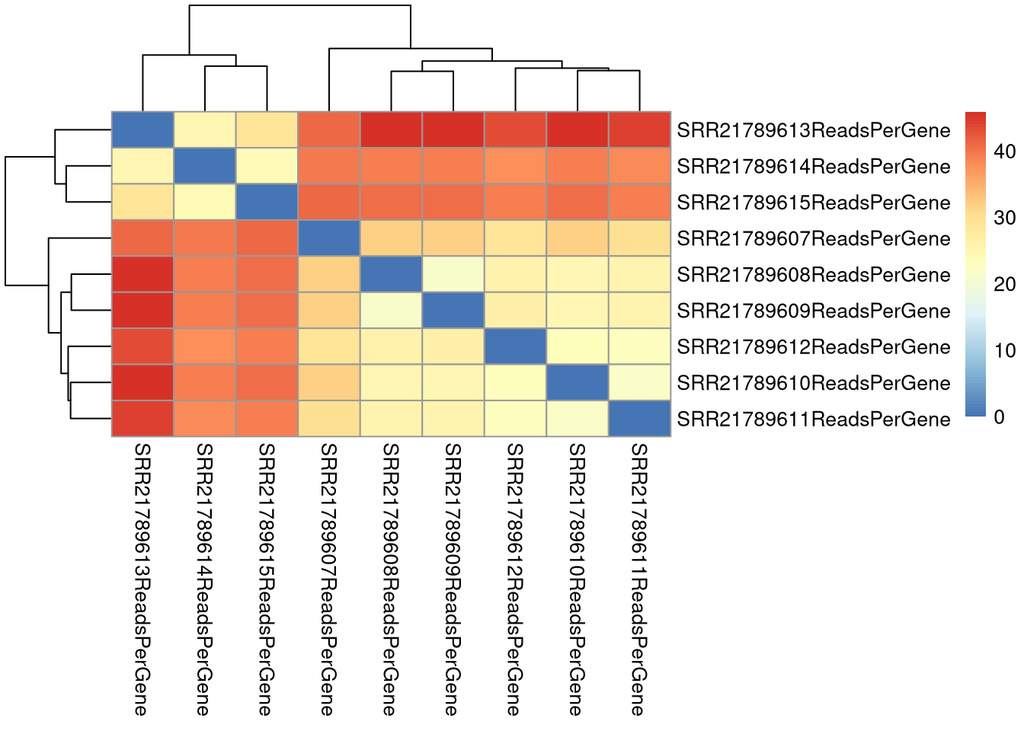

```r
library(pheatmap)

sampleDists <- dist(t(assay(rld_hg19)))
sampleDistMatrix <- as.matrix(sampleDists)

pheatmap(sampleDistMatrix)
```

### HG 38

```r
res_df_h38 <- as.data.frame(res_hg38)
res_df_h38$gene <- rownames(res_df_h38)
head(res_df_h38)
```

```
##           baseMean log2FoldChange     lfcSE       stat       pvalue
## TSPAN6 871.9516470      1.2440773 0.1847975  6.7321123 1.672175e-11
## TNMD     0.0000000             NA        NA         NA           NA
## DPM1   340.5073146     -0.1853494 0.1871795 -0.9902230 3.220652e-01
## SCYL3   88.9509081      1.1169487 0.2602152  4.2924034 1.767494e-05
## FIRRM  168.5294294      0.1790496 0.2735657  0.6545032 5.127877e-01
## FGR      0.1193704     -0.6102548 3.5338177 -0.1726899 8.628951e-01
##                padj   gene
## TSPAN6 4.119500e-10 TSPAN6
## TNMD             NA   TNMD
## DPM1   4.827932e-01   DPM1
## SCYL3  1.320307e-04  SCYL3
## FIRRM  6.614526e-01  FIRRM
## FGR              NA    FGR
```

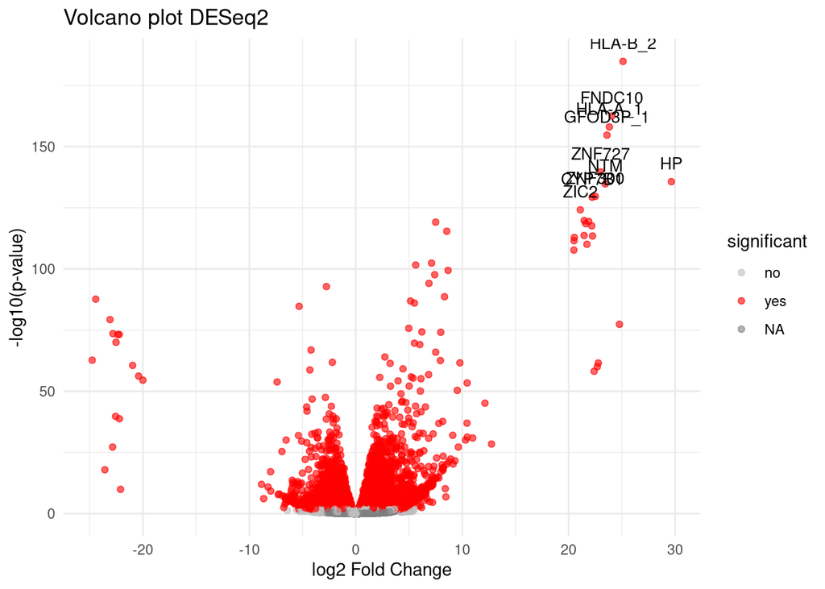

```r
res_df_h38 <- res_df_h38 %>%
  mutate(significant = ifelse(padj < 0.05, "yes", "no"))


top_genes <- res_df_h38 %>%
  filter(!is.na(padj)) %>%
  arrange(padj) %>%
  slice(1:10)

ggplot(res_df_h38, aes(x = log2FoldChange, y = -log10(pvalue))) +
  geom_point(aes(color = significant), alpha = 0.6) +
  scale_color_manual(values = c("no" = "grey", "yes" = "red")) +
  geom_text(data = top_genes,
            aes(label = gene),
            vjust = -1,
            size = 3.5) +
  theme_minimal() +
  labs(title = "Volcano plot DESeq2",
       x = "log2 Fold Change",
       y = "-log10(p-value)")
```

```r
rld_hg38 <- rlog(dds_hg38, blind=TRUE)
```

```
## -- note: fitType='parametric', but the dispersion trend was not well captured by the
##    function: y = a/x + b, and a local regression fit was automatically substituted.
##    specify fitType='local' or 'mean' to avoid this message next time.
```

```r
pcaData_hg38 <- plotPCA(rld_hg38, intgroup = c("genotype","treatment"), returnData = TRUE)
```

```
## using ntop=500 top features by variance
```

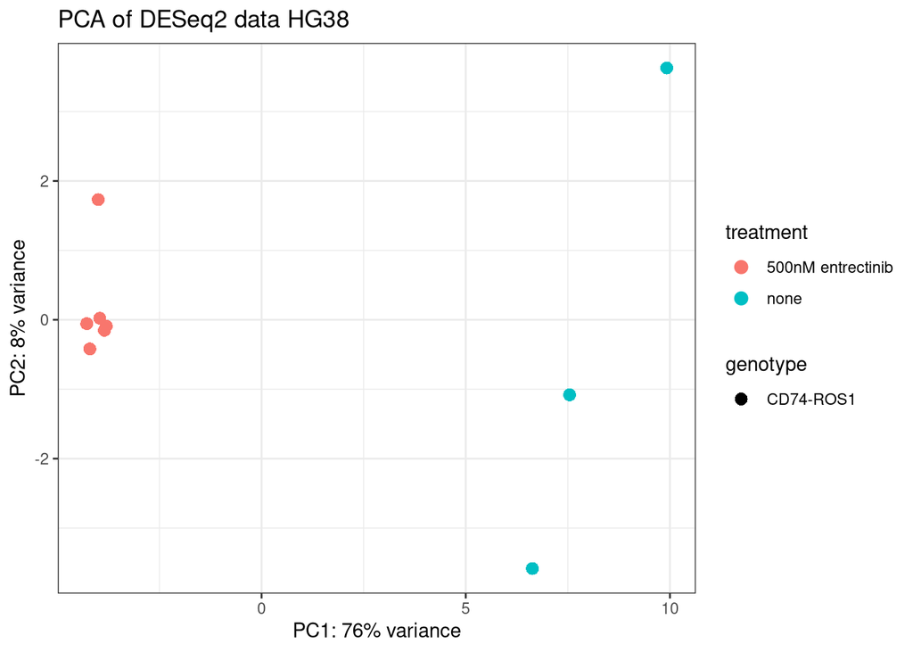

```r
percentVar <- round(100 * attr(pcaData_hg38, "percentVar"))
# Plot with ggplot2
ggplot(pcaData_hg38, aes(x=PC1, y=PC2, color=treatment, shape = genotype)) +
  geom_point(size=3) +
  xlab(paste0("PC1: ", percentVar[1], "% variance")) +
  ylab(paste0("PC2: ", percentVar[2], "% variance")) +
  theme_bw() +
  ggtitle("PCA of DESeq2 data HG38")
```

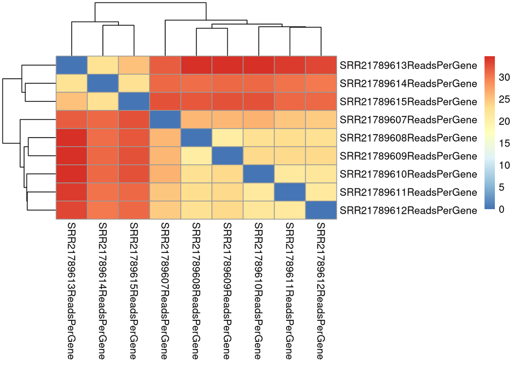

```r
sampleDists <- dist(t(assay(rld_hg38)))
sampleDistMatrix <- as.matrix(sampleDists)

pheatmap(sampleDistMatrix)
```